# SepticShockPrediction

## EARLY PREDICTION OF SEPTIC SHOCK - MACHINE LEARNING APPROACH

#### Load libraries

```r
library(readxl)
library(dplyr)
library(ggplot2)
library(caret)
library(doParallel)
library(e1071)
library(pROC)
library(data.table)
library(bimba)
library(kernlab)
library(corrplot)
library(stepPlr) # for penalized stepwise logistic
library(arm) # for bayesglm
library(caTools) # Boosted logistic regression
```

#### Load .RData file from local to avoid running all the models again

```
load("C:/Users/rsandhu/Desktop/R Documents and Code/Sepsis/RDataFiles/sepsis_1hr.RData")
```

#### Data Manipulation and Analysis

- Table name: nlp_dev.ml_sepsis_dataset_1_hr.
- Initially, don't drop any features. Consider dropping after analyzing missingness
- Missing values analysis before any manipulation

```r
rawFeatures_1_hr <- fread("sepsis_1_hour.csv", header = T, data.table = F)

missVal_1hr_all_features <- data.frame(number_of_missing_values = colSums(is.na(rawFeatures_1_hr))) %>%
  mutate(percent_missing = round(number_of_missing_values/nrow(rawFeatures_1_hr)*100, 2), features = names(rawFeatures_1_hr)) %>%
  select(features, number_of_missing_values, percent_missing)
```

```r
missVal_1hr_all_features
```

| features | number_of_missing_values | percent_missing |
| --- | --- | --- |
| ml_sepsis_dataset_1_hr.enc_csn_id | 0 | 0.00 |
| ml_sepsis_dataset_1_hr.aptt_patient | 35139 | 75.32 |
| ml_sepsis_dataset_1_hr.bilirubin__total | 28337 | 60.74 |
| ml_sepsis_dataset_1_hr.blood_culture | 0 | 0.00 |
| ml_sepsis_dataset_1_hr.bolus | 0 | 0.00 |
| ml_sepsis_dataset_1_hr.bp_diastolic | 2134 | 4.57 |
| ml_sepsis_dataset_1_hr.bp_systolic | 2094 | 4.49 |
| ml_sepsis_dataset_1_hr.call_sepsis_alert | 0 | 0.00 |
| ml_sepsis_dataset_1_hr.creatinine | 0 | 0.00 |
| ml_sepsis_dataset_1_hr.focused_exam | 0 | 0.00 |
| ml_sepsis_dataset_1_hr.glasgow_coma | 0 | 0.00 |
| ml_sepsis_dataset_1_hr.lactic_acid | 28696 | 61.51 |
| ml_sepsis_dataset_1_hr.map_(calculated) | 12270 | 26.30 |
| ml_sepsis_dataset_1_hr.mews_score_(auto_calculation) | 24666 | 52.87 |
| ml_sepsis_dataset_1_hr.platelet_count | 19691 | 42.21 |
| ml_sepsis_dataset_1_hr.pt/inr_inr | 28196 | 60.44 |
| ml_sepsis_dataset_1_hr.pulse | 1588 | 3.40 |
| ml_sepsis_dataset_1_hr.qsofa_(quick_sequential_organ_failure_assessment)_score | 45556 | 97.65 |
| ml_sepsis_dataset_1_hr.resp | 2011 | 4.31 |
| ml_sepsis_dataset_1_hr.temp | 3450 | 7.40 |
| ml_sepsis_dataset_1_hr.troponin | 0 | 0.00 |
| ml_sepsis_dataset_1_hr.vasosupressors | 0 | 0.00 |
| ml_sepsis_dataset_1_hr.wbc | 0 | 0.00 |
| ml_sepsis_dataset_1_hr.sepsis_type | 0 | 0.00 |
| ml_sepsis_dataset_1_hr.enc_age | 0 | 0.00 |
| ml_sepsis_dataset_1_hr.ethnicity | 0 | 0.00 |
| ml_sepsis_dataset_1_hr.gender | 0 | 0.00 |
| ml_sepsis_dataset_1_hr.height | 850 | 1.82 |
| ml_sepsis_dataset_1_hr.enc_type | 0 | 0.00 |
| ml_sepsis_dataset_1_hr.weight | 509 | 1.09 |

#### Dropping variables c(2,3,5,8,10,11,14,16,18,21,22,26,29) because either they have lot of missing data or not considered very useful at this point for the first iteration.

```r
rawFeatures_reduced_1 <- fread("sepsis_1_hour.csv", header = T, drop = c(2,3,5,8,10,11,14,16,18,21,22,26,29), data.table = F)

names(rawFeatures_reduced_1) <- sapply(strsplit(names(rawFeatures_reduced_1), split='.', fixed=TRUE), function(x) (x[2]))

cleanFeatureNames <- function(x)
{
  x %>%
    names() %>%
    gsub(pattern = "-", replacement = "_") %>%
    gsub(pattern = " ", replacement = "_") %>%
    gsub(pattern = "/", replacement = "_") %>%
    gsub(pattern = ",", replacement = "") %>%
    gsub(pattern = "`", replacement = "") %>%
    gsub(pattern = "(", replacement = "", fixed = T) %>% # pattern to be replaced can also be enclosed in
    gsub(pattern = ")", replacement = "", fixed = T) %>% # square brackets, no need of passing fixed argument then
    tolower()
}

names(rawFeatures_reduced_1) <- cleanFeatureNames(rawFeatures_reduced_1)
```

- Filter out creatinine values recorded as "YES" instead of numeric, "UNKNOWN" gender, missing height and weight as imputing them might not be the best approach, some of the wbc's have time stamp as a value so filter them out as well.
- Blood culture, Creatinine and wbc are character vectors with missing values not as NA but "". Following code handles that. For blood culture wherever there is any value - numeric or char, it is coded as 1 else 0. Idea was that if blood culture was taken then it should be coded as 1 irrespective of the results. Blood culture turn around is about 3 days. In case of creatinine, only the missing character values are encoded as NA. Similarly for wbc. Encode gender variable as 1 for male and 0 for female. Don't run this twice in a row as the values for blood culture will get messed up as per the code.

```r
rawFeatures_reduced_1 <- rawFeatures_reduced_1 %>% filter(creatinine != "YES" & gender != "UNKNOWN" & !is.na(height) &
                                        enc_csn_id != 219087207 & enc_csn_id != 211155235 & !is.na(weight))

rawFeatures_reduced_1 <- rawFeatures_reduced_1 %>% mutate(blood_culture = as.numeric(ifelse(blood_culture == "", 0, 1)),
                                                          creatinine = as.numeric(ifelse(creatinine == "", NA, creatinine)),
                                                          wbc = as.numeric(ifelse(wbc == "", NA, wbc)),
                                                          gender = as.numeric(ifelse(gender == "MALE", 1, 0)))
```

#### View the data and structure of predictors

```r
glimpse(rawFeatures_reduced_1)
```

```
Observations: 45,425
Variables: 17
$ enc_csn_id     <int> 101268209, 101401301, 101641353, 101878389, 10230324...
$ blood_culture  <dbl> 1, 1, 0, 0, 0, 0, 0, 0, 0, 0, 0, 1, 0, 1, 0, 0, 0, 1...
$ bp_diastolic   <int> 54, 46, 60, 85, 76, 52, 80, 54, 70, 48, 29, 38, 60, ...
$ bp_systolic    <int> 94, 116, 122, 187, 155, 113, 156, 110, 150, 102, 130...
$ creatinine     <dbl> 1.6, 3.0, NA, NA, NA, 2.3, 0.4, NA, 0.9, NA, 1.2, 0....
$ lactic_acid    <dbl> 2.6, 1.9, NA, NA, NA, NA, 1.2, NA, NA, NA, NA, 9.5, ...
$ map_calculated <dbl> 58.00, NA, 95.33, NA, 98.33, NA, 105.33, NA, 96.67, ...
$ platelet_count <int> 353, 58, NA, NA, NA, 266, 262, NA, 163, NA, 260, 209...
$ pulse          <dbl> 108, 96, 85, 96, 78, 81, 92, 133, 77, 86, 103, 110, ...
$ resp           <int> 22, 18, 12, 28, 22, 23, 20, 21, 18, 12, 26, 16, 18, ...
$ temp           <dbl> 101.2, 98.5, 97.2, 100.2, 97.5, 99.7, 98.4, 99.0, 98...
$ wbc            <dbl> 14.82, 10.82, NA, NA, NA, 9.10, 9.96, NA, 11.22, NA,...
$ sepsis_type    <chr> "SEVERE SEPSIS", "SEVERE SEPSIS", "SEPSIS", "SEPSIS"...
$ enc_age        <int> 72, 66, 77, 97, 87, 70, 87, 2, 79, 79, 85, 81, 54, 8...
$ gender         <dbl> 1, 1, 0, 0, 1, 1, 0, 1, 0, 1, 0, 1, 0, 0, 0, 0, 1, 1...
$ height         <int> 67, 72, 60, 63, 73, 64, 69, 30, 60, 68, 63, 68, 63, ...
$ weight         <int> 120, 202, 108, 128, 163, 173, 146, 26, 125, 135, 126...
```

#### Missing values

```r
missVal_1hr_post_filtering <- data.frame(number_of_missing_values = colSums(is.na(rawFeatures_reduced_1))) %>%
  mutate(percent_missing = round(number_of_missing_values/nrow(rawFeatures_reduced_1)*100, 2),
         features = names(rawFeatures_reduced_1)) %>%
  select(features, number_of_missing_values, percent_missing)
```

```r
missVal_1hr_post_filtering
```

| features | number_of_missing_values | percent_missing |
| --- | --- | --- |
| enc_csn_id | 0 | 0.00 |
| blood_culture | 0 | 0.00 |
| bp_diastolic | 1981 | 4.36 |
| bp_systolic | 1949 | 4.29 |
| creatinine | 19464 | 42.85 |
| lactic_acid | 27908 | 61.44 |
| map_calculated | 11725 | 25.81 |
| platelet_count | 19144 | 42.14 |
| pulse | 1458 | 3.21 |
| resp | 1852 | 4.08 |
| temp | 3260 | 7.18 |
| wbc | 19201 | 42.27 |
| sepsis_type | 0 | 0.00 |
| enc_age | 0 | 0.00 |
| gender | 0 | 0.00 |
| height | 0 | 0.00 |
| weight | 0 | 0.00 |

#### Analysis of individual patients within each cohort : Exploratory - not to be part of final script

- Create temp tables for SSPT and Control for further analysis

```r
SSPTraw_1 <- rawFeatures_reduced_1 %>%
  filter(sepsis_type == "SEPTIC SHOCK")

Controlraw_1 <- rawFeatures_reduced_1 %>%
  filter(sepsis_type != "SEPTIC SHOCK")
```

Histogram of distribution of temperature. Note that the data for temp is on 2 different scales, celsius and farenheit. The values on celsius scale need to be converted into farenheit. The plot below shows the same. The warnings about NAs in temp values are suppressed by wrapping the plot function in suppressWarnings function.

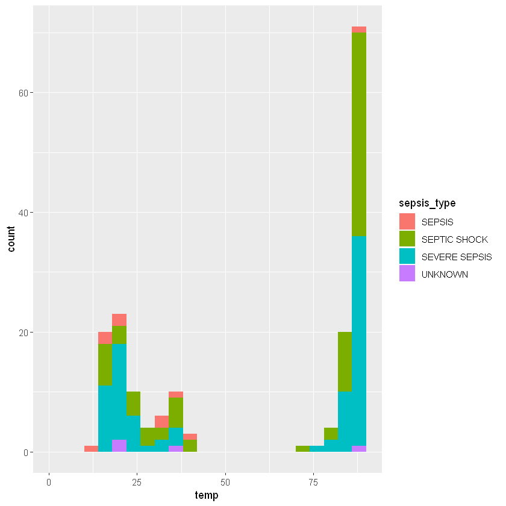

```r
suppressWarnings(print(ggplot(rawFeatures_reduced_1, aes(temp , fill = sepsis_type)) +
  geom_histogram(binwidth = 4) + xlim(0,90)))
```

#### Transformations of features

- Imputations and other transformations will be done on individual datasets viz SSPTraw_1 and Controlraw_1 and then rbind both
- Convert temp < 50 i.e. in celsius to Farenheit. There are 77 observations with temp likely to be on Celsius scale. Since the data is already split, convert these values for septic shock and control group patients separately.

```r
SSPTraw_1 <- SSPTraw_1 %>% mutate(temp = ifelse(temp < 50, temp * 9/5 + 32, temp))
Controlraw_1 <- Controlraw_1 %>% mutate(temp = ifelse(temp < 50, temp * 9/5 + 32, temp))
```

#### Imputation of missing values

- Check the median values before imputation and cross verify with confluence page (type of values)
- Impute missing feature values with median separately for SSPT and Control

```r
SSPTraw_1 %>% summarise(med = median(bp_diastolic,na.rm = T))
Controlraw_1 %>% summarise(med = median(bp_diastolic,na.rm = T))

# Impute bp_diastolic with median separately for SSPT and Control
SSPTraw_1 <- SSPTraw_1 %>%
  mutate(bp_diastolic = ifelse(is.na(bp_diastolic), median(bp_diastolic, na.rm = TRUE), bp_diastolic))

Controlraw_1 <- Controlraw_1 %>%
  mutate(bp_diastolic = ifelse(is.na(bp_diastolic), median(bp_diastolic, na.rm = TRUE), bp_diastolic))

# Impute bp_systolic with median separately for SSPT and Control
SSPTraw_1 <- SSPTraw_1 %>%
  mutate(bp_systolic = ifelse(is.na(bp_systolic), median(bp_systolic, na.rm = TRUE), bp_systolic))

Controlraw_1 <- Controlraw_1 %>%
  mutate(bp_systolic = ifelse(is.na(bp_systolic), median(bp_systolic, na.rm = TRUE), bp_systolic))

# Impute creatinine with median separately for SSPT and Control
SSPTraw_1 <- SSPTraw_1 %>%
  mutate(creatinine = ifelse(is.na(creatinine), median(creatinine, na.rm = TRUE), creatinine))

Controlraw_1 <- Controlraw_1 %>%
  mutate(creatinine = ifelse(is.na(creatinine), median(creatinine, na.rm = TRUE), creatinine))

# Impute lactic_acid with median separately for SSPT and Control
SSPTraw_1 <- SSPTraw_1 %>%
  mutate(lactic_acid = ifelse(is.na(lactic_acid), median(lactic_acid, na.rm = TRUE), lactic_acid))

Controlraw_1 <- Controlraw_1 %>%
  mutate(lactic_acid = ifelse(is.na(lactic_acid), median(lactic_acid, na.rm = TRUE), lactic_acid))

# Impute map_calculated with median separately for SSPT and Control
SSPTraw_1 <- SSPTraw_1 %>%
  mutate(map_calculated = ifelse(is.na(map_calculated), median(map_calculated, na.rm = TRUE), map_calculated))

Controlraw_1 <- Controlraw_1 %>%
  mutate(map_calculated = ifelse(is.na(map_calculated), median(map_calculated, na.rm = TRUE), map_calculated))

# Impute platelet_count with median separately for SSPT and Control
SSPTraw_1 <- SSPTraw_1 %>%
  mutate(platelet_count = ifelse(is.na(platelet_count), median(platelet_count, na.rm = TRUE), platelet_count))

Controlraw_1 <- Controlraw_1 %>%
  mutate(platelet_count = ifelse(is.na(platelet_count), median(platelet_count, na.rm = TRUE), platelet_count))

# Impute pulse with median separately for SSPT and Control
SSPTraw_1 <- SSPTraw_1 %>%
  mutate(pulse = ifelse(is.na(pulse), median(pulse, na.rm = TRUE), pulse))

Controlraw_1 <- Controlraw_1 %>%
  mutate(pulse = ifelse(is.na(pulse), median(pulse, na.rm = TRUE), pulse))

# Impute resp with median separately for SSPT and Control
SSPTraw_1 <- SSPTraw_1 %>%
  mutate(resp = ifelse(is.na(resp), median(resp, na.rm = TRUE), resp))

Controlraw_1 <- Controlraw_1 %>%
  mutate(resp = ifelse(is.na(resp), median(resp, na.rm = TRUE), resp))

# Impute temp with median separately for SSPT and Control
SSPTraw_1 <- SSPTraw_1 %>%
  mutate(temp = ifelse(is.na(temp), median(temp, na.rm = TRUE), temp))

Controlraw_1 <- Controlraw_1 %>%
  mutate(temp = ifelse(is.na(temp), median(temp, na.rm = TRUE), temp))

# Impute temp with median separately for SSPT and Control
SSPTraw_1 <- SSPTraw_1 %>%
  mutate(wbc = ifelse(is.na(wbc), median(wbc, na.rm = TRUE), wbc))

Controlraw_1 <- Controlraw_1 %>%
  mutate(wbc = ifelse(is.na(wbc), median(wbc, na.rm = TRUE), wbc))

# combine datasets SSPTraw and Controlraw
rawFeaturesImputed1 <- rbind(SSPTraw_1, Controlraw_1)

FinalmissVal1 <- data.frame(number_of_missing_values = colSums(is.na(rawFeaturesImputed1))) %>%
  mutate(percent_missing = round(number_of_missing_values/nrow(rawFeaturesImputed1)*100, 2),
         features = names(rawFeaturesImputed1)) %>%
  select(features, number_of_missing_values, percent_missing)
```

```r
FinalmissVal1
```

| features | number_of_missing_values | percent_missing |
| --- | --- | --- |
| enc_csn_id | 0 | 0 |
| blood_culture | 0 | 0 |
| bp_diastolic | 0 | 0 |
| bp_systolic | 0 | 0 |
| creatinine | 0 | 0 |
| lactic_acid | 0 | 0 |
| map_calculated | 0 | 0 |
| platelet_count | 0 | 0 |
| pulse | 0 | 0 |
| resp | 0 | 0 |
| temp | 0 | 0 |
| wbc | 0 | 0 |
| sepsis_type | 0 | 0 |
| enc_age | 0 | 0 |
| gender | 0 | 0 |
| height | 0 | 0 |
| weight | 0 | 0 |

#### MODEL BUILDING

- Run the following only once. Code the response variable and convert to factor. Also order the columns of predictor space to have response as the last column as required by the sampling techniques.

```r
rawFeaturesImputed1 <- rawFeaturesImputed1 %>%
  select(1:12,14:17,13) %>%
  mutate(sepsis_type = as.factor(ifelse(sepsis_type == "SEPTIC SHOCK", "YES", "NO")))
```

Taining and Test data split - 80/20 and evaluate the target class percentages

```r
set.seed(123)
dataSplit1 <- createDataPartition(rawFeaturesImputed1$sepsis_type, p = 0.8, list=F)
training1 <- rawFeaturesImputed1[dataSplit1, ]
testing1 <- rawFeaturesImputed1[-dataSplit1,]
```

```r
prop.table(table(training1$sepsis_type))
prop.table(table(testing1$sepsis_type))
```

```
       NO       YES
0.8630472 0.1369528
```

```
       NO       YES
0.8630559 0.1369441
```

```r
SmoteWithKNN <- read_excel("C:/Users/rsandhu/Desktop/R Documents and Code/Sepsis/SmoteWithKNN.xlsx")
```

- Chained sampling algorithms in sequence of cleaning with ENN, upsampling with SMOTE, class balancing with RUS.
- Optimise number of knn and sampling sequence (cleaning with ENN - remove majority/minority/both classes), precent of minority class upsampled.
- Run logisitic regression model and select the optimal parameters based on the AUC calculated on hold out dataset.

```r
SmoteWithKNN
```

| Number of original samples (Imbalance percentage) | Sampling Sequence | KNN in SMOTE and ENN | Percent of original minority class SMOTE sampled | Number of training samples post SMOTE (Minority percentage) | Model | AUC |
| --- | --- | --- | --- | --- | --- | --- |
| 36341 (86% Majority) | ENN (remove Majority), SMOTE (over sampling), RUS | 5 | 100 | 19908 (50%) | Logistic | 0.8836 |
| 36341 (86% Majority) | ENN (remove Majority), SMOTE (over sampling), RUS | 5 | 200 | 29862 (50%) | Logistic | 0.8835 |
| 36341 (86% Majority) | ENN (remove Majority), SMOTE (over sampling), RUS | 7 | 100 | 19908 (50%) | Logistic | 0.8835 |
| 36341 (86% Majority) | ENN (remove Majority), SMOTE (over sampling), RUS | 4 | 100 | 19908 (50%) | Logistic | 0.8600 |
| 36341 (86% Majority) | ENN (remove Majority), SMOTE (over sampling), RUS | 10 | 100 | 19908 (50%) | Logistic | 0.8600 |
| 36341 (86% Majority) | ENN (remove Majority), SMOTE (over sampling), RUS | 6 | 100 | 19908 (50%) | Logistic | 0.8598 |
| 36341 (86% Majority) | ENN (remove Minority), SMOTE (over sampling), RUS | 5 | 100 | 8880 (50%) | Logistic | 0.8225 |
| 36341 (86% Majority) | ENN (remove Both), SMOTE (over sampling), RUS | 5 | 100 | 8880 (50%) | Logistic | 0.8208 |
| 36341 (86% Majority) | NRAS, SMOTE | 5 | Auto | 62717 (50%) | Logistic | 0.8138 |

#### Synthetic sampling and class balancing

- The only restriction on the data for the use of the SMOTE function implemented in bimba is that the predictors must be numeric and the target must be both the last column of the data frame that holds your data and have only two values. As long as the data abide by these restrictions, using the SMOTE function is easy: Source : [Bimba github](https://github.com/RomeroBarata/bimba)
- SMOTE is not robust to noisy minority examples. Adding a cleaning step to the majority class before using SMOTE. This exercise removes the observations from the majority class which are miss-classified by their knn. This can be used for majority or minority class, decided based on exploration of original and smoted data.
- Clean using ENN, double the size of the minority class using SMOTE and balance the distribution using RUS.

```r
algorithms <- c("ENN", "SMOTE", "RUS")
parameters <- list(
  ENN = list(remove_class = "Majority", k = 5),
  SMOTE = list(perc_over = 100, k = 5),
  RUS = list(perc_maj = 50)
)

set.seed(123)
smoteTrain1 <- sampling_sequence(training1[ ,2:17], algorithms = algorithms,
                                 parameters = parameters)
```

```r
head(smoteTrain1)
```

|  | blood_culture | bp_diastolic | bp_systolic | creatinine | lactic_acid | map_calculated | platelet_count | pulse | resp | temp | wbc | enc_age | gender | height | weight | sepsis_type |
| --- | --- | --- | --- | --- | --- | --- | --- | --- | --- | --- | --- | --- | --- | --- | --- | --- |
| 1 | 1 | 38 | 49 | 0.9 | 9.5 | 62.00 | 209 | 110 | 16 | 99.4 | 19.38 | 81 | 1 | 68 | 269 | YES |
| 2 | 0 | 0 | 70 | 1.4 | 3.5 | 23.33 | 202 | 148 | 44 | 102.4 | 13.60 | 54 | 0 | 65 | 108 | YES |
| 4 | 1 | 65 | 113 | 1.9 | 6.7 | 81.00 | 152 | 72 | 28 | 98.2 | 19.04 | 47 | 0 | 62 | 350 | YES |
| 5 | 1 | 60 | 92 | 3.4 | 1.9 | 70.67 | 96 | 118 | 19 | 102.9 | 7.80 | 43 | 0 | 67 | 271 | YES |
| 7 | 0 | 35 | 61 | 5.3 | 3.4 | 43.67 | 95 | 83 | 17 | 96.4 | 3.29 | 89 | 1 | 70 | 193 | YES |
| 8 | 0 | 78 | 111 | 1.4 | 3.5 | 89.00 | 202 | 114 | 20 | 98.8 | 13.60 | 63 | 1 | 68 | 198 | YES |

#### Correlation Analysis

- Omitting the NAs (13819 complete cases) and using the continuous predictors for correlation analysis.
- The correlation plot is generated with complete cases of data before any imputations or pre-processing.

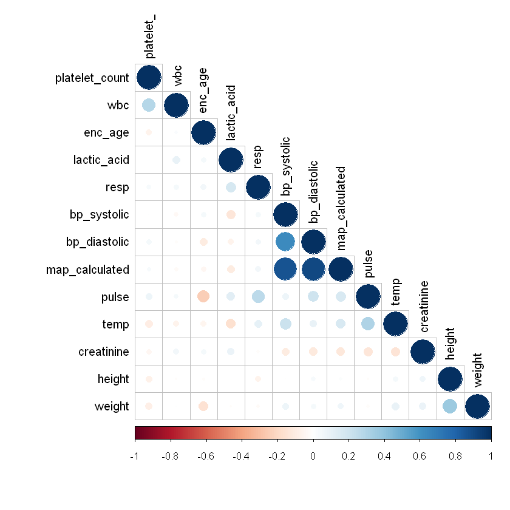

```r
sepsisCorr1 <- cor(na.omit(rawFeatures_reduced_1[, c(3:12,14,16:17)]))

corrplot::corrplot(sepsisCorr1, method = "circle", order = "hclust", type = "lower",
                   mar = c(1, 0, 1, 1), tl.cex = 1, tl.col = "black")
```

#### Set Train Control

```r
set.seed(123)
ctrl <- trainControl(method = "cv",
                      number = 10,
                      summaryFunction = twoClassSummary,
                      classProbs = T,
                      allowParallel = T,
                      savePredictions = T)
```

#### Logistic Regression

Remove predictors bp_diastolic, temp, resp, wbc, map_calculated as they appear last in the variable importance profile and the p-values for coefficient estimates are not statistically significant. Removing these predictors didn't affect the model performance. Boxcox transformation was applied to 2 continuous predictors to remove skewness.

```r
set.seed(123)
logisticFit <- caret::train(sepsis_type ~ . -bp_diastolic -temp -resp -wbc -map_calculated,
                         data = smoteTrain1,
                         method="glm",
                         metric = "ROC",
                         preProcess = c("BoxCox"),
                         family= binomial(link = "logit"),
                         trControl = ctrl)
```

```r
logisticFit
summary(logisticFit)
```

```
Generalized Linear Model

19908 samples
   15 predictor
    2 classes: 'NO', 'YES'

Pre-processing: Box-Cox transformation (2)
Resampling: Cross-Validated (10 fold)
Summary of sample sizes: 17918, 17918, 17918, 17917, 17918, 17916, ...
Resampling results:

  ROC        Sens       Spec
  0.9055438  0.8824579  0.8417737
```

```
Call:
NULL

Deviance Residuals:
    Min       1Q   Median       3Q      Max
-8.4904  -0.5832  -0.0387   0.6208   3.3225

Coefficients:
                 Estimate Std. Error z value Pr(>|z|)
(Intercept)    -5.192e+00  1.933e-01 -26.855  < 2e-16 ***
blood_culture   1.306e+00  4.342e-02  30.084  < 2e-16 ***
bp_systolic    -1.185e-02  7.631e-04 -15.532  < 2e-16 ***
creatinine      4.484e-01  5.097e-02   8.799  < 2e-16 ***
lactic_acid     1.800e+00  2.677e-02  67.260  < 2e-16 ***
platelet_count -5.152e-04  2.219e-04  -2.322  0.02025 *
pulse           5.266e-03  9.248e-04   5.695 1.24e-08 ***
enc_age         5.503e-03  1.195e-03   4.606 4.11e-06 ***
gender         -2.343e-01  4.624e-02  -5.067 4.04e-07 ***
height          4.346e-04  6.603e-05   6.581 4.66e-11 ***
weight         -1.151e-03  3.559e-04  -3.235  0.00122 **
---
Signif. codes:  0 '***' 0.001 '**' 0.01 '*' 0.05 '.' 0.1 ' ' 1

(Dispersion parameter for binomial family taken to be 1)

    Null deviance: 27598  on 19907  degrees of freedom
Residual deviance: 15869  on 19897  degrees of freedom
AIC: 15891

Number of Fisher Scoring iterations: 7
```

#### Regularized Logistic Regression

```r
set.seed(123)
RegularizedLogisticFit <- caret::train(sepsis_type ~ .,
                            data = smoteTrain1,
                            method="regLogistic",
                            metric = "ROC",
                            trControl = ctrl)
```

```r
RegularizedLogisticFit
```

```
Regularized Logistic Regression

19908 samples
   15 predictor
    2 classes: 'NO', 'YES'

No pre-processing
Resampling: Cross-Validated (10 fold)
Summary of sample sizes: 17917, 17917, 17918, 17916, 17916, 17917, ...
Resampling results across tuning parameters:

  cost  loss       epsilon  ROC        Sens       Spec
  0.5   L1         0.001    0.9076185  0.8862772  0.8396646
  0.5   L1         0.010    0.9074680  0.8861768  0.8397647
  0.5   L1         0.100    0.9056867  0.8859758  0.8363494
  0.5   L2_dual    0.001    0.8969070  0.8999229  0.6548491
  0.5   L2_dual    0.010    0.8989887  0.7269482  0.7441003
  0.5   L2_dual    0.100    0.8992351  0.7932221  0.7550452
  0.5   L2_primal  0.001    0.9069268  0.8865787  0.8403679
  0.5   L2_primal  0.010    0.9062641  0.8889903  0.8389612
  0.5   L2_primal  0.100    0.8877808  0.9076739  0.8099231
  1.0   L1         0.001    0.9077597  0.8859760  0.8393633
  1.0   L1         0.010    0.9074947  0.8859759  0.8397647
  1.0   L1         0.100    0.9056780  0.8859761  0.8363492
  1.0   L2_dual    0.001    0.8850961  0.7066768  0.7776729
  1.0   L2_dual    0.010    0.9022222  0.8276475  0.7656541
  1.0   L2_dual    0.100    0.8878359  0.7405182  0.7467109
  1.0   L2_primal  0.001    0.9069346  0.8865790  0.8398654
  1.0   L2_primal  0.010    0.9066700  0.8872821  0.8391623
  1.0   L2_primal  0.100    0.8877358  0.9077743  0.8098226
  2.0   L1         0.001    0.9078057  0.8861769  0.8393634
  2.0   L1         0.010    0.9075329  0.8861768  0.8400663
  2.0   L1         0.100    0.9057697  0.8850720  0.8373539
  2.0   L2_dual    0.001    0.9008435  0.8172082  0.7133200
  2.0   L2_dual    0.010    0.8955000  0.6770561  0.7297126
  2.0   L2_dual    0.100    0.8985623  0.8957127  0.6140132
  2.0   L2_primal  0.001    0.9070748  0.8866789  0.8401669
  2.0   L2_primal  0.010    0.9067136  0.8877843  0.8399660
  2.0   L2_primal  0.100    0.8879407  0.9066692  0.8109277

ROC was used to select the optimal model using the largest value.
The final values used for the model were cost = 2, loss = L1 and epsilon
 = 0.001.
```

#### Bayesian Generalized Linear Model

```r
BayesglmFit <- caret::train(sepsis_type ~ .,
                            data = smoteTrain1,
                            method="bayesglm",
                            metric = "ROC",
                            preProc = c("center", "scale"),
                            trControl = ctrl)
```

```r
BayesglmFit
summary(BayesglmFit)
```

```
Bayesian Generalized Linear Model

19908 samples
   15 predictor
    2 classes: 'NO', 'YES'

Pre-processing: centered (15), scaled (15)
Resampling: Cross-Validated (10 fold)
Summary of sample sizes: 17917, 17918, 17917, 17917, 17918, 17917, ...
Resampling results:

  ROC        Sens       Spec
  0.9076524  0.8861763  0.8406687
```

```
Call:
NULL

Deviance Residuals:
    Min       1Q   Median       3Q      Max
-8.4904  -0.5844  -0.0442   0.6231   3.1342

Coefficients:
               Estimate Std. Error z value Pr(>|z|)
(Intercept)     0.86060    0.02564  33.564  < 2e-16 ***
blood_culture   0.62706    0.02208  28.403  < 2e-16 ***
bp_diastolic    0.02186    0.03706   0.590  0.55522
bp_systolic    -0.30218    0.03529  -8.563  < 2e-16 ***
creatinine      0.09627    0.02014   4.781 1.74e-06 ***
lactic_acid     4.00259    0.05886  67.996  < 2e-16 ***
map_calculated -0.08679    0.03495  -2.483  0.01302 *
platelet_count -0.06276    0.02189  -2.867  0.00415 **
pulse           0.12365    0.02545   4.858 1.19e-06 ***
resp            0.01549    0.02478   0.625  0.53183
temp            0.02536    0.02466   1.028  0.30383
wbc             0.01014    0.02299   0.441  0.65928
enc_age         0.10804    0.02448   4.412 1.02e-05 ***
gender         -0.08435    0.02193  -3.846  0.00012 ***
height          0.20906    0.03073   6.803 1.03e-11 ***
weight         -0.07424    0.02410  -3.081  0.00206 **
---
Signif. codes:  0 '***' 0.001 '**' 0.01 '*' 0.05 '.' 0.1 ' ' 1

(Dispersion parameter for binomial family taken to be 1)

    Null deviance: 27598  on 19907  degrees of freedom
Residual deviance: 15901  on 19892  degrees of freedom
AIC: 15933

Number of Fisher Scoring iterations: 7
```

```r
BoostedLogisticFit <- caret::train(sepsis_type ~ .,
                            data = smoteTrain1,
                            method="LogitBoost",
                            metric = "ROC",
                            preProc = c("center", "scale"),
                            trControl = ctrl)
```

```r
BoostedLogisticFit
```

```
Boosted Logistic Regression

19908 samples
   15 predictor
    2 classes: 'NO', 'YES'

Pre-processing: centered (15), scaled (15)
Resampling: Cross-Validated (10 fold)
Summary of sample sizes: 17916, 17916, 17917, 17917, 17918, 17917, ...
Resampling results across tuning parameters:

  nIter  ROC        Sens       Spec
  11     0.9399578  0.9002470  0.8409699
  21     0.9486127  0.8761227  0.8781456
  31     0.9551134  0.8770372  0.8867853

ROC was used to select the optimal model using the largest value.
The final value used for the model was nIter = 31.
```

#### C5.0 (Best performing model based on AUROC metrics)

```r
set.seed(123)
C5Fit <- caret::train(sepsis_type ~ .,
                            data = smoteTrain1,
                            method="C5.0",
                            metric = "ROC",
                            trControl = ctrl)
```

```r
C5Fit
```

```
C5.0

19908 samples
   15 predictor
    2 classes: 'NO', 'YES'

No pre-processing
Resampling: Cross-Validated (10 fold)
Summary of sample sizes: 17918, 17918, 17918, 17917, 17918, 17916, ...
Resampling results across tuning parameters:

  model  winnow  trials  ROC        Sens       Spec
  rules  FALSE    1      0.9190173  0.8871828  0.8976290
  rules  FALSE   10      0.9744876  0.9083766  0.9171201
  rules  FALSE   20      0.9779753  0.9172161  0.9173193
  rules   TRUE    1      0.9232196  0.8940086  0.8935129
  rules   TRUE   10      0.9737204  0.8962238  0.9214371
  rules   TRUE   20      0.9766617  0.9085801  0.9159110
  tree   FALSE    1      0.9622459  0.8709034  0.9042555
  tree   FALSE   10      0.9727945  0.8982317  0.9151096
  tree   FALSE   20      0.9763751  0.9064696  0.9202335
  tree    TRUE    1      0.9633903  0.8709053  0.9064650
  tree    TRUE   10      0.9719862  0.8969245  0.9144071
  tree    TRUE   20      0.9750651  0.9043589  0.9135024

ROC was used to select the optimal model using the largest value.
The final values used for the model were trials = 20, model = rules and
 winnow = FALSE.
```

#### Decision Tree

```r
treeFit <- caret::train(sepsis_type ~ .,
                        data = smoteTrain1,
                        method="rpart",
                        metric = "ROC",
                        tuneLength = 30,
                        trControl = ctrl,
                        parms=list(split='information'))
```

```r
treeFit
```

```
CART

19908 samples
   15 predictor
    2 classes: 'NO', 'YES'

No pre-processing
Resampling: Cross-Validated (10 fold)
Summary of sample sizes: 17917, 17917, 17918, 17917, 17917, 17917, ...
Resampling results across tuning parameters:

  cp            ROC        Sens       Spec
  0.0002176679  0.9533407  0.8797449  0.8896912
  0.0002210167  0.9533407  0.8797449  0.8896912
  0.0002296277  0.9553146  0.8784384  0.8953173
  0.0002385975  0.9552847  0.8780368  0.8962219
  0.0003013864  0.9578564  0.8747212  0.9030528
  0.0003348738  0.9586769  0.8752237  0.9039576
  0.0003516174  0.9596408  0.8749219  0.9045604
  0.0004018485  0.9592841  0.8738173  0.9061684
  0.0004353359  0.9568392  0.8741193  0.9061687
  0.0004520796  0.9572813  0.8713052  0.9063685
  0.0005023106  0.9561302  0.8714049  0.9056648
  0.0005525417  0.9541898  0.8709010  0.9046597
  0.0005625879  0.9536140  0.8699970  0.9042571
  0.0006027728  0.9529947  0.8697970  0.9046599
  0.0007032349  0.9531404  0.8666820  0.9078754
  0.0007367223  0.9531594  0.8651752  0.9088801
  0.0007534659  0.9531594  0.8651752  0.9088801
  0.0008036970  0.9529169  0.8631658  0.9105876
  0.0008371844  0.9529169  0.8631658  0.9105876
  0.0009041591  0.9504959  0.8585453  0.9123958
  0.0011050834  0.9465066  0.8543266  0.9131000
  0.0011553144  0.9464271  0.8535216  0.9136021
  0.0015069319  0.9461083  0.8519152  0.9122949
  0.0018585493  0.9328408  0.8401636  0.9185264
  0.0026120153  0.9298104  0.8374488  0.9203326
  0.0028464269  0.9297924  0.8382528  0.9183242
  0.0033152502  0.9206373  0.8416690  0.9082801
  0.0034659433  0.9167832  0.8446829  0.9024509
  0.0049226442  0.8804847  0.8792453  0.8553362
  0.7317661242  0.7165765  0.7325844  0.7005686

ROC was used to select the optimal model using the largest value.
The final value used for the model was cp = 0.0003516174.
```

#### svm Radial

```r
set.seed(123)
sigmaRange <- sigest(as.matrix(smoteTrain1[, 1:15]))
svmRGrid <- expand.grid(sigma = sigmaRange[1],
                        C = 2^(seq(-4, 4)))

set.seed(123)
svmRFit <- caret::train(sepsis_type ~ .,
                       data = smoteTrain1,
                       method = "svmRadial",
                       metric = "ROC",
                       preProc = c("center", "scale"),
                       tuneGrid = svmRGrid,
                       trControl = ctrl)
```

```r
svmRFit
```

```
Support Vector Machines with Radial Basis Function Kernel

19908 samples
   15 predictor
    2 classes: 'NO', 'YES'

Pre-processing: centered (15), scaled (15)
Resampling: Cross-Validated (10 fold)
Summary of sample sizes: 17918, 17918, 17918, 17917, 17918, 17916, ...
Resampling results across tuning parameters:

  C        ROC        Sens       Spec
   0.0625  0.9033790  0.9002407  0.8244940
   0.1250  0.9042825  0.9012456  0.8281102
   0.2500  0.9074417  0.8987344  0.8316264
   0.5000  0.9120421  0.8966242  0.8366493
   1.0000  0.9165899  0.8935096  0.8414717
   2.0000  0.9212115  0.8908982  0.8478015
   4.0000  0.9246393  0.8874820  0.8537285
   8.0000  0.9272963  0.8843671  0.8595542
  16.0000  0.9290370  0.8808506  0.8660842

Tuning parameter 'sigma' was held constant at a value of 0.01898621
ROC was used to select the optimal model using the largest value.
The final values used for the model were sigma = 0.01898621 and C = 16.
```

#### Variable importance profiles

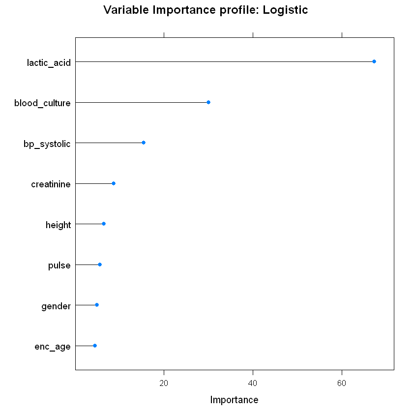

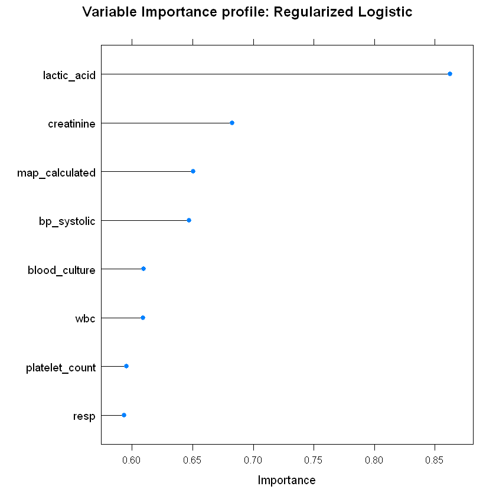

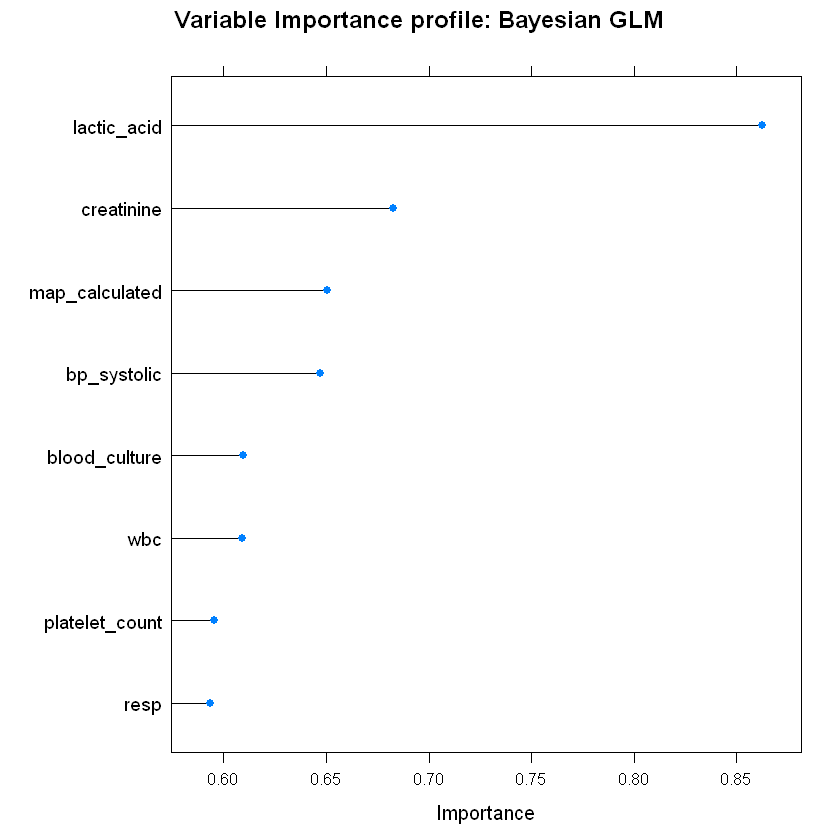

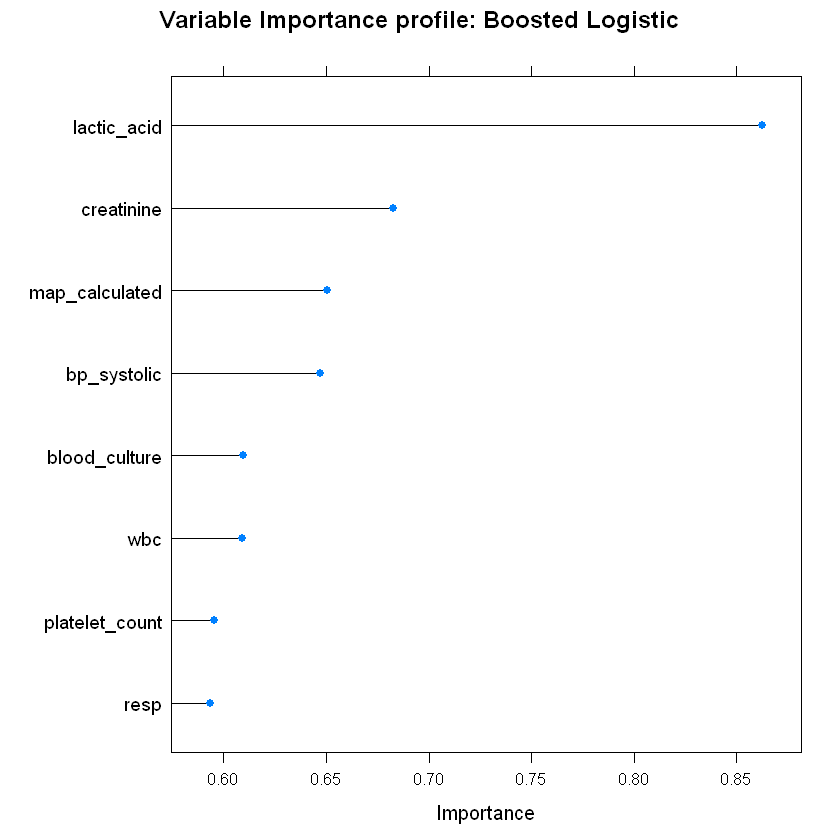

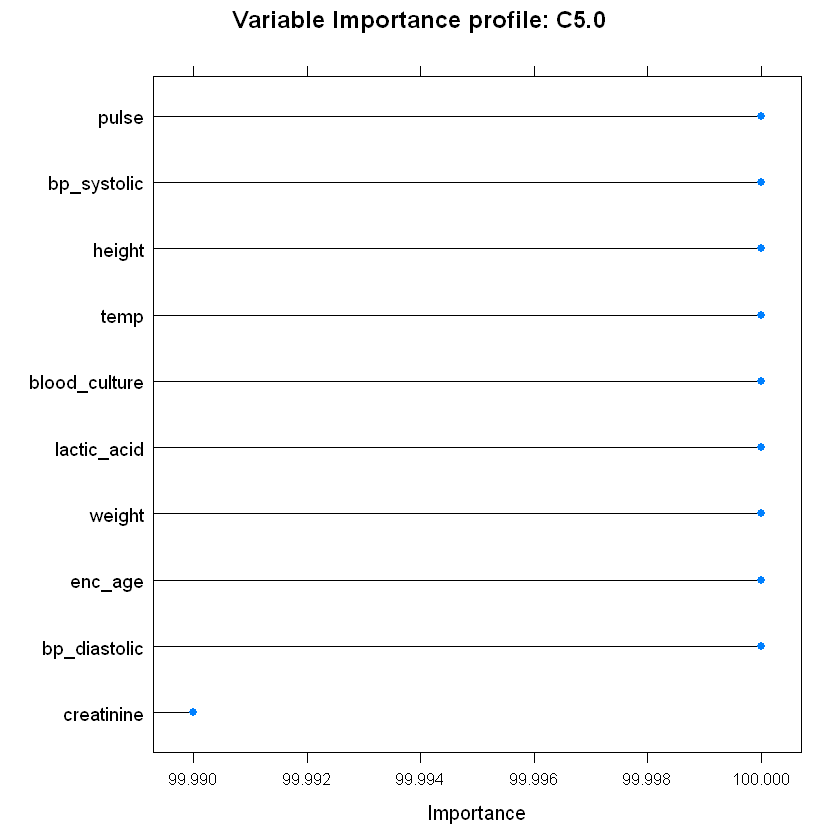

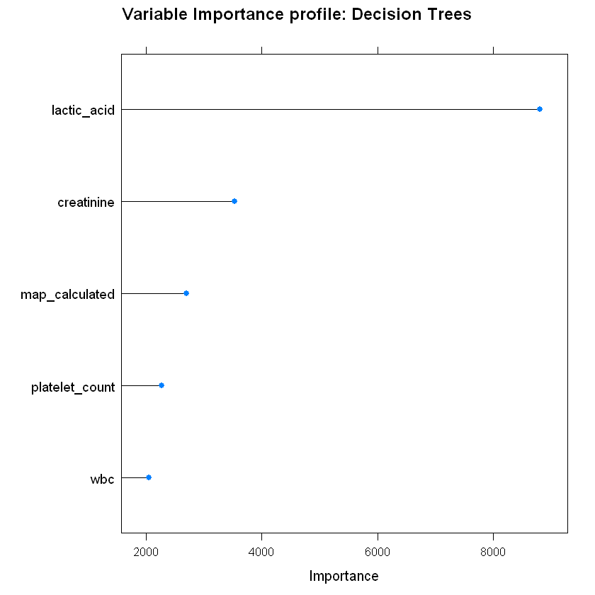

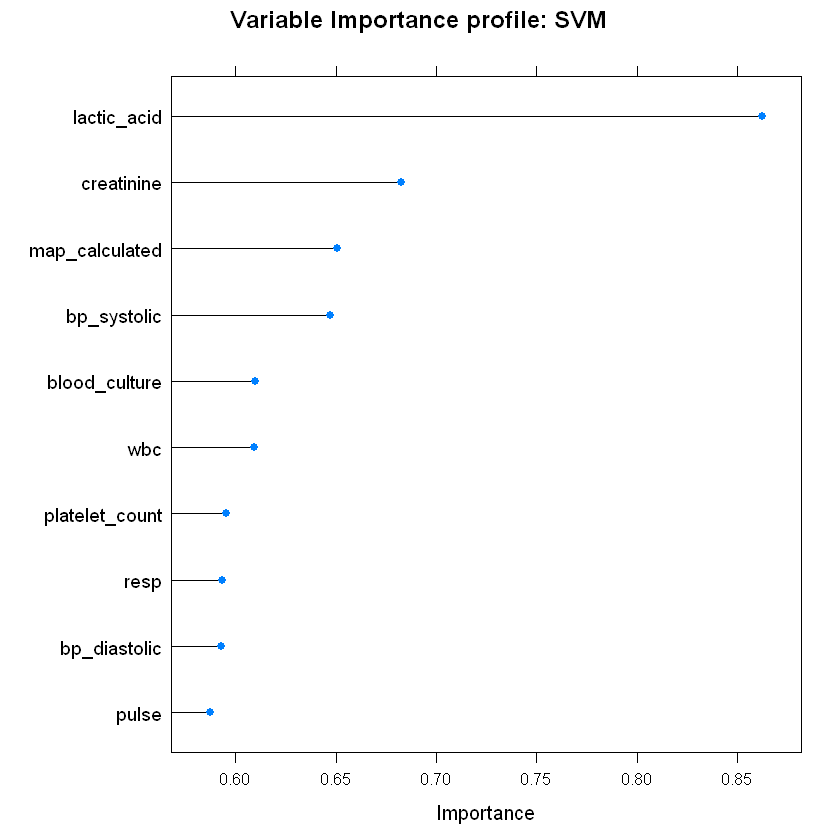

```r
logisticFit.Imp <- varImp(logisticFit, scale = F)
plot(logisticFit.Imp, top = 8,
     scales = list(y = list(cex = .95)),
     main = "Variable Importance profile: Logistic")

RegularizedLogisticFit.Imp <- varImp(RegularizedLogisticFit, scale = F)
plot(RegularizedLogisticFit.Imp, top = 8,
     scales = list(y = list(cex = .95)),
     main = "Variable Importance profile: Regularized Logistic")

BayesglmFit.Imp <- varImp(BayesglmFit, scale = F)
plot(BayesglmFit.Imp, top = 8,
     scales = list(y = list(cex = .95)),
     main = "Variable Importance profile: Bayesian GLM")

BoostedLogisticFit.Imp <- varImp(BoostedLogisticFit, scale = F)
plot(BoostedLogisticFit.Imp, top = 8,
     scales = list(y = list(cex = .95)),
     main = "Variable Importance profile: Boosted Logistic")

C5Fit.Imp <- varImp(C5Fit, scale = F)
plot(C5Fit.Imp, top = 10,
     scales = list(y = list(cex = .95)),
     main = "Variable Importance profile: C5.0")

treeFit.Imp <- varImp(treeFit, scale = F)
plot(treeFit.Imp, top = 5,
     scales = list(y = list(cex = .95)),
     main = "Variable Importance profile: Decision Trees")

svmRFit.Imp <- varImp(svmRFit, scale = F)
plot(svmRFit.Imp, top = 10,
     scales = list(y = list(cex = .95)),
     main = "Variable Importance profile: SVM")
```

#### Plots of ROC (Hyper parameter tuning - cross validation)

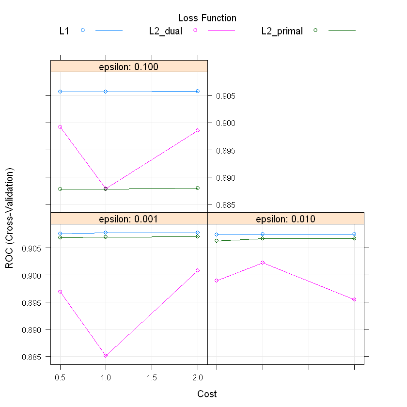

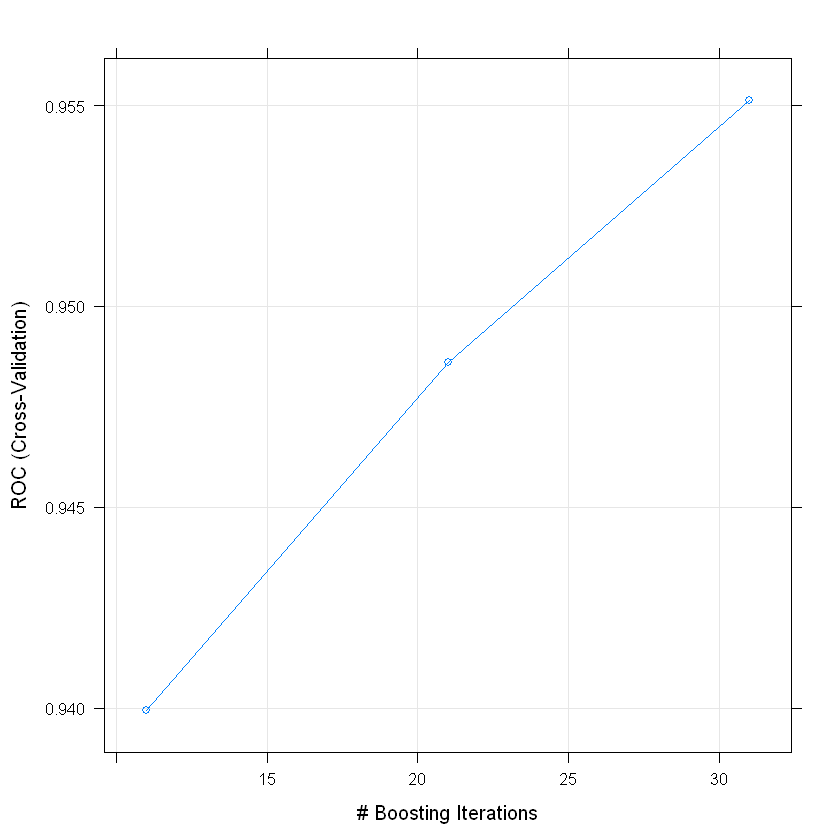

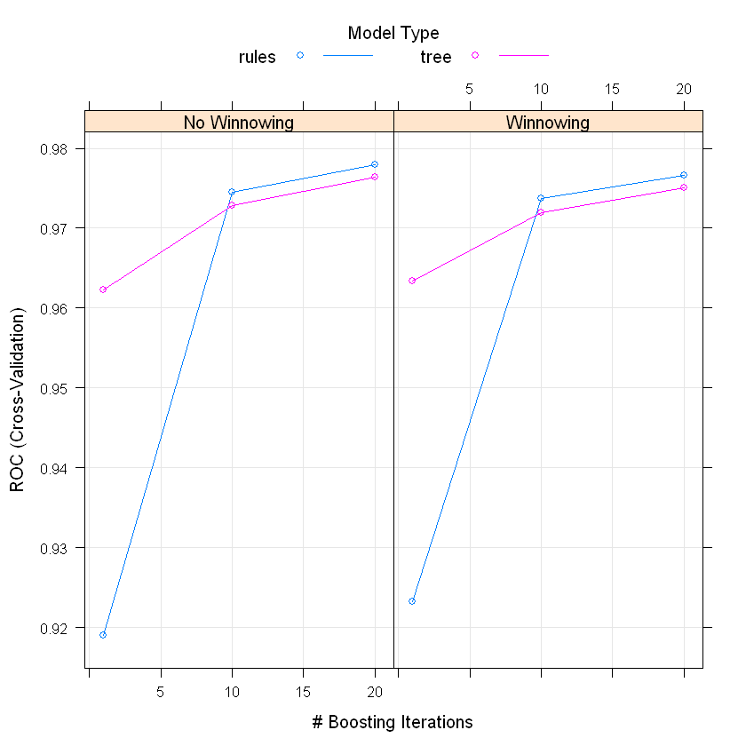

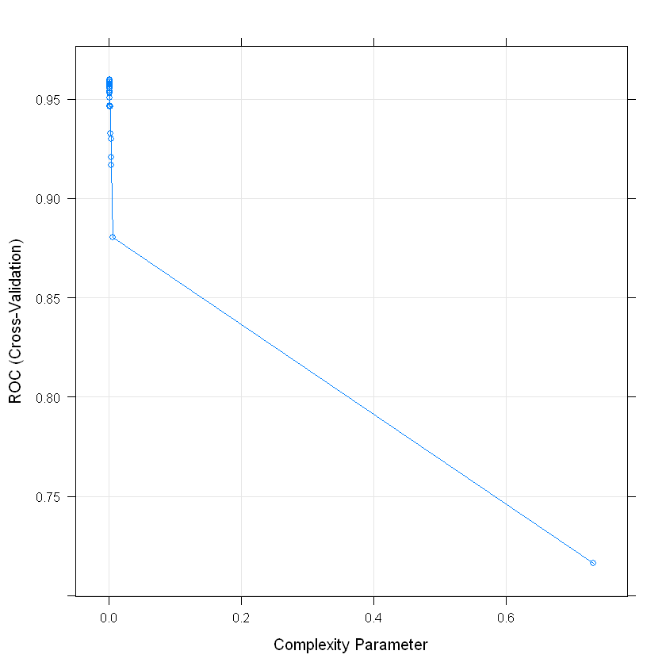

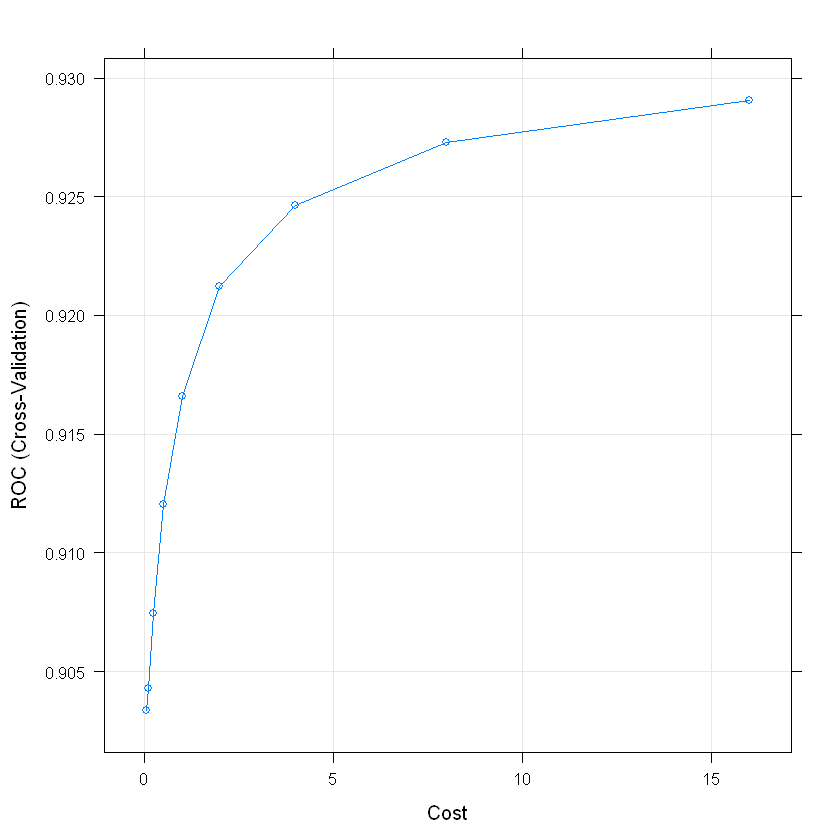

```r
plot(RegularizedLogisticFit)

plot(BoostedLogisticFit)

plot(C5Fit)

plot(treeFit)

plot(svmRFit)
```

## Testing/predicting the hold out data

#### Predictions - Raw and Probabilities (hold out test data). Raw for confusion matrices and prob for roc curves

```r
predLogisticFit.prob <- predict(logisticFit, testing1[ , 2:16], type = "prob")
predLogisticFit.raw <- predict(logisticFit, testing1[ , 2:16], type = "raw")

RegularizedLogisticFit.prob <- predict(RegularizedLogisticFit, testing1[ , 2:16], type = "prob")
RegularizedLogisticFit.raw <- predict(RegularizedLogisticFit, testing1[ , 2:16], type = "raw")

BayesglmFit.prob <- predict(BayesglmFit, testing1[ , 2:16], type = "prob")
BayesglmFit.raw <- predict(BayesglmFit, testing1[ , 2:16], type = "raw")

BoostedLogisticFit.prob <- predict(BoostedLogisticFit, testing1[ , 2:16], type = "prob")
BoostedLogisticFit.raw <- predict(BoostedLogisticFit, testing1[ , 2:16], type = "raw")

predC5Fit.prob <- predict(C5Fit, testing1[ , 2:16], type = "prob")
predC5Fit.raw <- predict(C5Fit, testing1[ , 2:16], type = "raw")

predTreeFit.prob <- predict(treeFit, testing1[ , 2:16], type = "prob")
predTreeFit.raw <- predict(treeFit, testing1[ , 2:16], type = "raw")

predsvmRFit.prob <- predict(svmRFit, testing1[ , 2:16], type = "prob")
predsvmRFit.raw <- predict(svmRFit, testing1[ , 2:16], type = "raw")
```

#### Confusion Matrix - Logistic

```r
cm.LogisticFit <- confusionMatrix(data = predLogisticFit.raw,
                                  reference = testing1$sepsis_type,
                                  positive = "YES")
cm.LogisticFit
```

```
Confusion Matrix and Statistics

          Reference
Prediction   NO  YES
       NO  6760  211
       YES 1080 1033

               Accuracy : 0.8579
                 95% CI : (0.8505, 0.865)
    No Information Rate : 0.8631
    P-Value [Acc > NIR] : 0.9259

                  Kappa : 0.5353
 Mcnemar's Test P-Value : <2e-16

            Sensitivity : 0.8304
            Specificity : 0.8622
         Pos Pred Value : 0.4889
         Neg Pred Value : 0.9697
             Prevalence : 0.1369
         Detection Rate : 0.1137
   Detection Prevalence : 0.2326
      Balanced Accuracy : 0.8463

       'Positive' Class : YES
```

#### Confusion Matrix - Regularized logistic

```r
cm.RegularizedLogisticFit <- confusionMatrix(data = RegularizedLogisticFit.raw,
                                             reference = testing1$sepsis_type,
                                             positive = "YES")
cm.RegularizedLogisticFit
```

```
Confusion Matrix and Statistics

          Reference
Prediction   NO  YES
       NO  6754  213
       YES 1086 1031

               Accuracy : 0.857
                 95% CI : (0.8496, 0.8641)
    No Information Rate : 0.8631
    P-Value [Acc > NIR] : 0.9542

                  Kappa : 0.5329
 Mcnemar's Test P-Value : <2e-16

            Sensitivity : 0.8288
            Specificity : 0.8615
         Pos Pred Value : 0.4870
         Neg Pred Value : 0.9694
             Prevalence : 0.1369
         Detection Rate : 0.1135
   Detection Prevalence : 0.2330
      Balanced Accuracy : 0.8451

       'Positive' Class : YES
```

#### Confusion Matrix - Bayesian GLM

```r
cm.BayesglmFit <- confusionMatrix(data = BayesglmFit.raw,
                                  reference = testing1$sepsis_type,
                                  positive = "YES")
cm.BayesglmFit
```

```
Confusion Matrix and Statistics

          Reference
Prediction   NO  YES
       NO  6762  214
       YES 1078 1030

               Accuracy : 0.8578
                 95% CI : (0.8504, 0.8649)
    No Information Rate : 0.8631
    P-Value [Acc > NIR] : 0.93

                  Kappa : 0.5344
 Mcnemar's Test P-Value : <2e-16

            Sensitivity : 0.8280
            Specificity : 0.8625
         Pos Pred Value : 0.4886
         Neg Pred Value : 0.9693
             Prevalence : 0.1369
         Detection Rate : 0.1134
   Detection Prevalence : 0.2321
      Balanced Accuracy : 0.8452

       'Positive' Class : YES
```

#### Confusion Matrix - Boosted logistic

```r
cm.BoostedLogisticFit <- confusionMatrix(data = BoostedLogisticFit.raw,
                                         reference = testing1$sepsis_type,
                                         positive = "YES")
cm.BoostedLogisticFit
```

```
Confusion Matrix and Statistics

          Reference
Prediction   NO  YES
       NO  6623  208
       YES 1217 1036

               Accuracy : 0.8431
                 95% CI : (0.8355, 0.8506)
    No Information Rate : 0.8631
    P-Value [Acc > NIR] : 1

                  Kappa : 0.5052
 Mcnemar's Test P-Value : <2e-16

            Sensitivity : 0.8328
            Specificity : 0.8448
         Pos Pred Value : 0.4598
         Neg Pred Value : 0.9696
             Prevalence : 0.1369
         Detection Rate : 0.1140
   Detection Prevalence : 0.2480
      Balanced Accuracy : 0.8388

       'Positive' Class : YES
```

#### Confusion Matrix - C5.0

```r
cm.C5Fit <- confusionMatrix(data = predC5Fit.raw,
                            reference = testing1$sepsis_type,
                            positive = "YES")
cm.C5Fit
```

```
Confusion Matrix and Statistics

          Reference
Prediction   NO  YES
       NO  7012  238
       YES  828 1006

               Accuracy : 0.8827
                 95% CI : (0.8759, 0.8892)
    No Information Rate : 0.8631
    P-Value [Acc > NIR] : 1.609e-08

                  Kappa : 0.5861
 Mcnemar's Test P-Value : < 2.2e-16

            Sensitivity : 0.8087
            Specificity : 0.8944
         Pos Pred Value : 0.5485
         Neg Pred Value : 0.9672
             Prevalence : 0.1369
         Detection Rate : 0.1107
   Detection Prevalence : 0.2019
      Balanced Accuracy : 0.8515

       'Positive' Class : YES
```

#### Confusion Matrix - Decision Tree

```r
cm.treeFit <- confusionMatrix(data = predTreeFit.raw,
                              reference = testing1$sepsis_type,
                              positive = "YES")
cm.treeFit
```

```
Confusion Matrix and Statistics

          Reference
Prediction   NO  YES
       NO  6724  180
       YES 1116 1064

               Accuracy : 0.8573
                 95% CI : (0.85, 0.8645)
    No Information Rate : 0.8631
    P-Value [Acc > NIR] : 0.9448

                  Kappa : 0.5416
 Mcnemar's Test P-Value : <2e-16

            Sensitivity : 0.8553
            Specificity : 0.8577
         Pos Pred Value : 0.4881
         Neg Pred Value : 0.9739
             Prevalence : 0.1369
         Detection Rate : 0.1171
   Detection Prevalence : 0.2400
      Balanced Accuracy : 0.8565

       'Positive' Class : YES
```

#### Confusion Matrix - SVM Radial

```r
cm.svmRFit <- confusionMatrix(data = predsvmRFit.raw,
                              reference = testing1$sepsis_type,
                              positive = "YES")
cm.svmRFit
```

```
Confusion Matrix and Statistics

          Reference
Prediction   NO  YES
       NO  6672  207
       YES 1168 1037

               Accuracy : 0.8486
                 95% CI : (0.8411, 0.8559)
    No Information Rate : 0.8631
    P-Value [Acc > NIR] : 1

                  Kappa : 0.5167
 Mcnemar's Test P-Value : <2e-16

            Sensitivity : 0.8336
            Specificity : 0.8510
         Pos Pred Value : 0.4703
         Neg Pred Value : 0.9699
             Prevalence : 0.1369
         Detection Rate : 0.1142
   Detection Prevalence : 0.2427
      Balanced Accuracy : 0.8423

       'Positive' Class : YES
```

#### ROC curves (creating objects for plotting)

```r
roc.LogisticFit <- roc(response = testing1$sepsis_type,
                       predictor = predLogisticFit.prob[,"YES"],
                       levels = levels(testing1$sepsis_type))

roc.RegularizedLogisticFit <- roc(response = testing1$sepsis_type,
                                  predictor = RegularizedLogisticFit.prob[,"YES"],
                                  levels = levels(testing1$sepsis_type))

roc.BayesglmFit <- roc(response = testing1$sepsis_type,
                       predictor = BayesglmFit.prob[,"YES"],
                       levels = levels(testing1$sepsis_type))

roc.BoostedLogisticFit <- roc(response = testing1$sepsis_type,
                                  predictor = BoostedLogisticFit.prob[,"YES"],
                                  levels = levels(testing1$sepsis_type))

roc.C5Fit <- roc(response = testing1$sepsis_type,
                 predictor = predC5Fit.prob[,"YES"],
                 levels = levels(testing1$sepsis_type))

roc.treeFit <- roc(response = testing1$sepsis_type,
                   predictor = predTreeFit.prob[,"YES"],
                   levels = levels(testing1$sepsis_type))

roc.svmRFit <- roc(response = testing1$sepsis_type,
                   predictor = predsvmRFit.prob[,"YES"],
                   levels = levels(testing1$sepsis_type))
```

#### ROC curves

- ASP = NA adresses the problem of x-axis being padded print.thres = T is one of the arguments that can be passed to first plotting function but need to be investigated as it gives a weird threshold vale which seems to be too low.

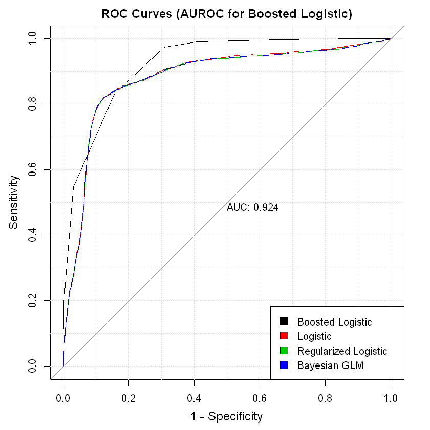

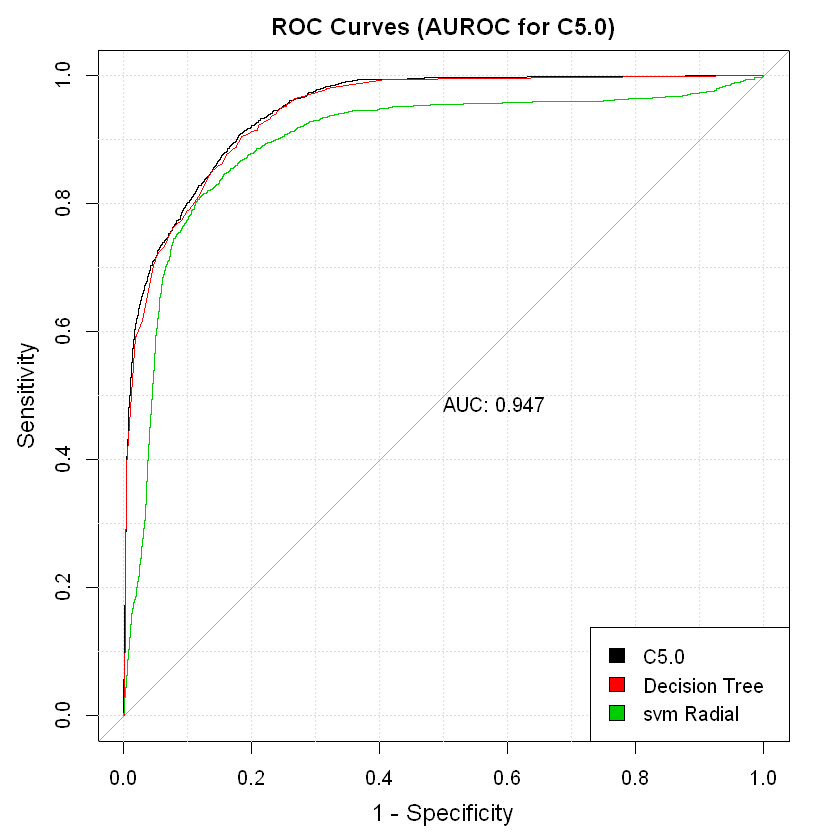

```r
plot(roc.BoostedLogisticFit, legacy.axes = T, col = 1, lty = 1, lwd = 1,
     main = "ROC Curves (AUROC for Boosted Logistic)", print.auc = T,
     grid = T, cex.lab = 1.2, asp = NA)

plot(roc.LogisticFit, legacy.axes = T, col = 2, add = TRUE, lty = 1, lwd = 1)

plot(roc.RegularizedLogisticFit, legacy.axes = T, col = 3, add = TRUE, lty = 1, lwd = 1)

plot(roc.BayesglmFit, legacy.axes = T, col = 4, add = TRUE, lty = 1, lwd = 1)

legend(x = "bottomright",
       legend = c("Boosted Logistic", "Logistic", "Regularized Logistic", "Bayesian GLM"),
       fill = 1:4)


plot(roc.C5Fit, legacy.axes = T, col = 1, lty = 1, lwd = 1,
     main = "ROC Curves (AUROC for C5.0)", print.auc = T,
     grid = T, cex.lab = 1.2, asp = NA)

plot(roc.treeFit, legacy.axes = T, col = 2, add = TRUE, lty = 1, lwd = 1)

plot(roc.svmRFit, legacy.axes = T, col = 3, add = TRUE, lty = 1, lwd = 1)

legend(x = "bottomright",
       legend = c("C5.0", "Decision Tree", "svm Radial"),
       fill = 1:3)
```